# get data

```python
import pandas as pd
import numpy as np
import matplotlib.pyplot as plt
from statsmodels.stats.anova import AnovaRM
from scipy.stats import ttest_rel
from scipy.stats import mannwhitneyu
from scipy.stats import describe
from scipy.stats import ttest_ind
from scipy.stats import wilcoxon
import seaborn as sb

path = '~/Desktop/v1Data/'
name = ['S20-20_Sorted_TEWL_V1_4Sponsor.xlsx','S20-20_Sorted_Erythema_V1_4Sponsor.xlsx','S20-20_Sorted_Denudation_V1_4Sponsor.xlsx']

# read pH
pHdf = pd.read_excel('~/Desktop/v1Data/S20-20_pH_V1_4Sponsor.xlsx',sheet_name='pH')
pHdf.head()

dc = {'ID':[],'IPtype':[],'time':[],'TEWL':[],'Erythema':[],'Denudation':[],'pH':[]}
all_time = [0,3,5,6]
num_par = 25
num_type = 2
time = 4
for i in range(num_par):
    for j in range(len(all_time)):
        dc['ID'] += [i+1]
        dc['IPtype'] += ['A']
        dc['time'] += [all_time[j]]
        dc['pH'] += [pHdf['pH'].iloc[i]]
for i in range(num_par):
    for j in range(len(all_time)):
        dc['ID'] += [i+1]
        dc['IPtype'] += ['B']
        dc['time'] += [all_time[j]]
        dc['pH'] += [pHdf['pH'].iloc[i]]

key = ['TEWL','Erythema','Denudation']
v11AB = {}
for doc in range(len(name)):
# for doc in range(2,3):
    v11=pd.read_excel(path+name[doc],sheet_name='v1-1')
    v11 = v11.reset_index(drop=True)
    v11_A = v11.iloc[:,:5];
    v11_A = v11_A.rename(columns={"#":"id","A BL": "0", "A 3": "3", "A 5": "5", "A 6": "6"})
    v11_A.insert(1,'IP','A')
    v11_B = v11.iloc[:,[0,5,6,7,8]];
    v11_B = v11_B.rename(columns={"#":"id","B BL": "0", "B 3": "3", "B 5": "5", "B 6": "6"})
    v11_B.insert(1,'IP','B')
    v11AB[key[doc]+"_A"] = v11_A
    v11AB[key[doc]+"_B"] = v11_B

    for i in range(v11_A.shape[0]):
        for j in range(len(all_time)):
            dc[key[doc]] += [(v11_A.iloc[i])[str(all_time[j])]]

    for i in range(v11_B.shape[0]):
        for j in range(len(all_time)):
            dc[key[doc]] += [(v11_B.iloc[i])[str(all_time[j])]]

dfall = pd.DataFrame(dc)
dfall.head()
```

|  | ID | IPtype | time | TEWL | Erythema | Denudation | pH |
| --- | --- | --- | --- | --- | --- | --- | --- |
| 0 | 1 | A | 0 | 3.455 | 0 | 0 | 6.630000 |
| 1 | 1 | A | 3 | 9.760 | 2 | 0 | 6.630000 |
| 2 | 1 | A | 5 | 48.000 | 4 | 2 | 6.630000 |
| 3 | 1 | A | 6 | 68.475 | 6 | 2 | 6.630000 |
| 4 | 2 | A | 0 | 2.825 | 0 | 0 | 6.446667 |

# prepare data: for each subject, get their maximum TEWL for Flextend (A) and Ceraplus (B), and the maximum of the two

```python
df_TEWL = pd.concat([v11AB['TEWL_A'],v11AB['TEWL_B']])
df_TEWL['0-3'] = (df_TEWL['3']-df_TEWL['0'])
df_TEWL['3-5'] = (df_TEWL['5']-df_TEWL['3'])
df_TEWL['5-6'] = df_TEWL['6']-df_TEWL['5']
df_TEWL['maxAB']=0 # initialize max
df_TEWL['maxA']=0 # initialize max
df_TEWL['maxB']=0 # initialize max
df_TEWL['maxA-0']=0 # initialize max
df_TEWL['maxB-0']=0 # initialize max
df_TEWL = df_TEWL.reset_index(drop=True)
```

```python
# print(df_TEWL['0-3'].var(axis=0)/9)
# print(df_TEWL['3-5'].var(axis=0)/4)
# print(df_TEWL['5-6'].var(axis=0))
```

```python
## add maxAB, maxA, maxB
for i in range(num_par):
    maxAB = max((df_TEWL[df_TEWL.id==i+1])['6'])
    maxA = float((df_TEWL[(df_TEWL.id==i+1)&(df_TEWL.IP=='A')])['6'])
    maxB = float((df_TEWL[(df_TEWL.id==i+1)&(df_TEWL.IP=='B')])['6'])
    df_TEWL.loc[i,'maxAB'] = maxAB
    df_TEWL.loc[i+25,'maxAB'] = maxAB
    df_TEWL.loc[i,'maxA'] = maxA
    df_TEWL.loc[i+25,'maxA'] = maxA
    df_TEWL.loc[i,'maxA-0'] = maxA - float((df_TEWL[(df_TEWL.id==i+1)&(df_TEWL.IP=='A')])['0'])
    df_TEWL.loc[i+25,'maxA-0'] = maxA - float((df_TEWL[(df_TEWL.id==i+1)&(df_TEWL.IP=='A')])['0'])
    df_TEWL.loc[i,'maxB'] = maxB
    df_TEWL.loc[i+25,'maxB'] = maxB
    df_TEWL.loc[i,'maxB-0'] = maxB - float((df_TEWL[(df_TEWL.id==i+1)&(df_TEWL.IP=='B')])['0'])
    df_TEWL.loc[i+25,'maxB-0'] = maxB - float((df_TEWL[(df_TEWL.id==i+1)&(df_TEWL.IP=='B')])['0'])
```

## calculate percentage increase separately for A and B, based on maxA and maxB respectively

```python
df_TEWLA = df_TEWL[df_TEWL.IP =='A']
df_TEWLB = df_TEWL[df_TEWL.IP =='B']
pct_list = list(df_TEWLA['0-3']/df_TEWLA['maxA']*100)+list((df_TEWLB['0-3']/df_TEWLB['maxB']*100))
df_TEWL['0-3percent'] = pct_list
pct_list = list(df_TEWLA['3-5']/df_TEWLA['maxA']*100)+list((df_TEWLB['3-5']/df_TEWLB['maxB']*100))
df_TEWL['3-5percent'] = pct_list
pct_list = list(df_TEWLA['5-6']/df_TEWLA['maxA']*100)+list((df_TEWLB['5-6']/df_TEWLB['maxB']*100))
df_TEWL['5-6percent'] = pct_list
```

## calculate percentage increase based on maxAB, no matter A or B

```python
df_TEWL['0-3percentAB'] = df_TEWL['0-3']/df_TEWL['maxAB']*100
df_TEWL['3-5percentAB'] = df_TEWL['3-5']/df_TEWL['maxAB']*100
df_TEWL['5-6percentAB'] = df_TEWL['5-6']/df_TEWL['maxAB']*100
```

```python
df_TEWL.head()
```

|  | id | IP | 0 | 3 | 5 | 6 | 0-3 | 3-5 | 5-6 | maxAB | maxA | maxB | maxA-0 | maxB-0 | 0-3percent | 3-5percent | 5-6percent | 0-3percentAB | 3-5percentAB | 5-6percentAB |
| --- | --- | --- | --- | --- | --- | --- | --- | --- | --- | --- | --- | --- | --- | --- | --- | --- | --- | --- | --- | --- |
| 0 | 1 | A | 3.455 | 9.76 | 48.000 | 68.475 | 6.305 | 38.240 | 20.475 | 68.475 | 68.475 | 24.545 | 65.020 | 21.935 | 9.207740 | 55.845199 | 29.901424 | 9.207740 | 55.845199 | 29.901424 |
| 1 | 2 | A | 2.825 | 2.61 | 9.495 | 17.370 | -0.215 | 6.885 | 7.875 | 17.370 | 17.370 | 4.775 | 14.545 | 1.265 | -1.237766 | 39.637306 | 45.336788 | -1.237766 | 39.637306 | 45.336788 |
| 2 | 3 | A | 3.220 | 13.94 | 41.250 | 53.725 | 10.720 | 27.310 | 12.475 | 53.725 | 53.725 | 52.730 | 50.505 | 48.410 | 19.953467 | 50.832946 | 23.220102 | 19.953467 | 50.832946 | 23.220102 |
| 3 | 4 | A | 3.515 | 18.59 | 57.540 | 78.340 | 15.075 | 38.950 | 20.800 | 78.340 | 78.340 | 10.670 | 74.825 | 6.095 | 19.243043 | 49.719173 | 26.550932 | 19.243043 | 49.719173 | 26.550932 |
| 4 | 5 | A | 4.905 | 28.52 | 68.465 | 77.770 | 23.615 | 39.945 | 9.305 | 77.770 | 77.770 | 22.835 | 72.865 | 19.465 | 30.365179 | 51.362993 | 11.964768 | 30.365179 | 51.362993 | 11.964768 |

# Analysis based on percentage change

## distribution of TEWL percentage change from peel0 to peel3, peel3 to peel5, and peel5 to peel6, percentage calculated based on the maximum of (maxTEWL_A, maxTEWL_B)

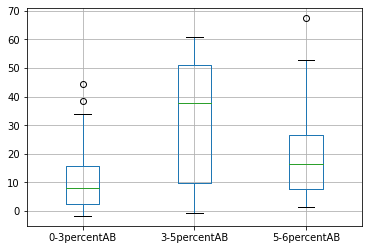

```python
df_TEWL.boxplot(column=['0-3percentAB','3-5percentAB','5-6percentAB'])
```

##### if only look at distribution percentage increase based on AB, regardless of treatments, we can see that netchange in 3-5 contributes most to the final value.

## percentage change based on maxA and maxB separately (TEWL)

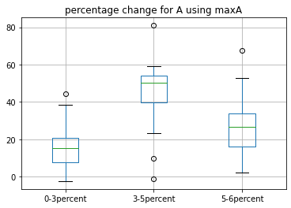

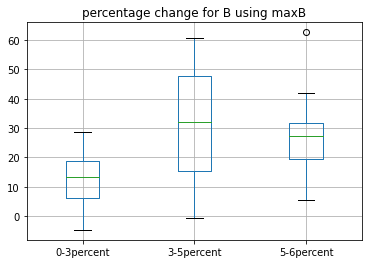

```python
percentage_columns = ['0-3percent','3-5percent','5-6percent']
df_TEWL[df_TEWL.IP=='A'].boxplot(column=percentage_columns)
plt.title('percentage change for A using maxA')
plt.show()
df_TEWL[df_TEWL.IP=='B'].boxplot(column=percentage_columns)
plt.title('percentage change for B using maxB')
plt.show()
```

## compare each increase for A and B

```
WilcoxonResult(statistic=109.0, pvalue=0.15633821487426758)
```

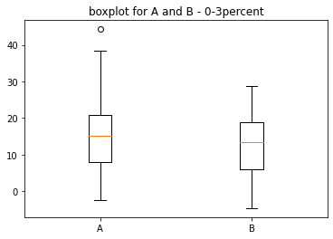

```
WilcoxonResult(statistic=63.0, pvalue=0.006129205226898193)
```

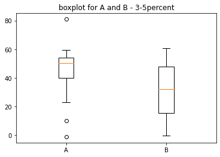

```
WilcoxonResult(statistic=150.0, pvalue=0.7509929537773132)
```

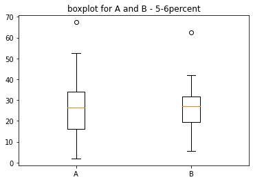

```python
percentage_columns = ['0-3percent','3-5percent','5-6percent']
for p in percentage_columns:
    boxdict={}
    boxdict['A']=(df_TEWL[df_TEWL.IP=='A'])[p]
    boxdict['B']=(df_TEWL[df_TEWL.IP=='B'])[p]
    print(wilcoxon(boxdict['A'],boxdict['B']))
    plt.boxplot(boxdict.values(),labels=['A','B'])
    plt.title('boxplot for A and B - '+ p)
    plt.show()
```

##### pooling the individuals

- when plotting the increase for each treatment(percentage of maxA if under treatmentA, percentage of B if under treatment B),
- we can see that even though netchange in 3-5 contributes most to the final value, netchange in 3-5 seems to contribute to A more than B, and 3-5 percentage for B has a larger variance.
- The difference in increase for A and B is not so dramatic for 0-3 and 5-6 percentage. By Wilcoxon test, only 3-5 percentage change for A and B is different significantly at p =0.1

# Use boxplot to display overall distribution of TEWL percentage changes at period (peel0-3, peel3-5, peel5-6), based on maximum TEWL for A and B separately

```python
# percentage_columns = ['0-3percent','3-5percent','5-6percent']
# for key in group:
#     g = group[key]
#     df_TEWL_group = df_TEWL[df_TEWL.id.isin(g)]
#     boxdict={}
#     for p in range(len(percentage_columns)):
# #         boxdict[percentage_columns[p]]=(df_TEWL_group[df_TEWL_group.IP=='A'])[percentage_columns[p]]
#         boxdict[percentage_columns[p]]=df_TEWL_group[percentage_columns[p]]
#     plt.boxplot(boxdict.values(),labels=percentage_columns)
#     plt.title(key+'-boxplot for A and B')
#     plt.show()
```

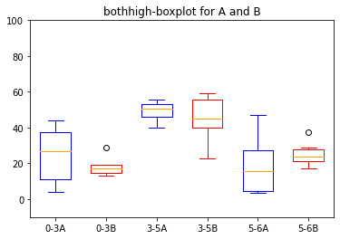

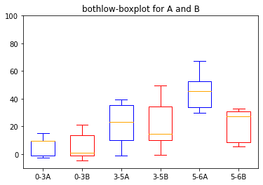

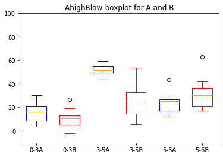

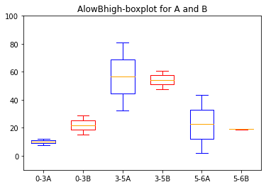

```python
from pylab import plot, show, savefig, xlim, figure,ylim, legend, boxplot, setp, axes
def setBoxColors(bp):
    plt.setp(bp['boxes'][0], color='blue')
    plt.setp(bp['caps'][0], color='blue')
    plt.setp(bp['caps'][1], color='blue')
    plt.setp(bp['whiskers'][0], color='blue')
    plt.setp(bp['whiskers'][1], color='blue')
    plt.setp(bp['fliers'][0], color='blue')
    plt.setp(bp['fliers'][1], color='blue')
    plt.setp(bp['medians'][0], color='orange')

    plt.setp(bp['boxes'][1], color='red')
    plt.setp(bp['caps'][2], color='red')
    plt.setp(bp['caps'][3], color='red')
    plt.setp(bp['whiskers'][2], color='red')
    plt.setp(bp['whiskers'][3], color='red')
#     plt.setp(bp['fliers'][2], color='red')
#     plt.setp(bp['fliers'][3], color='red')
    plt.setp(bp['medians'][1], color='orange')

percentage_columns = ['0-3percent','3-5percent','5-6percent']
for key in group:
    g = group[key]
    df_TEWL_group = df_TEWL[df_TEWL.id.isin(g)]
    pos = 0;
    fig = figure()
    ax = axes()
    for p in range(len(percentage_columns)):
#     for p in range(len(percentage_columns)):
        boxdict={}
        boxlist = []
        boxdict['A']=(df_TEWL_group[df_TEWL_group.IP=='A'])[percentage_columns[p]]
        boxdict['B']=(df_TEWL_group[df_TEWL_group.IP=='B'])[percentage_columns[p]]
        boxlist = [boxdict['A']]+[boxdict['B']]
        bp = plt.boxplot(boxlist, positions = [pos+1, pos+2], widths = 0.6)
        setBoxColors(bp)
        pos += 2;
    ax.set_xticklabels(['0-3A','0-3B','3-5A','3-5B','5-6A','5-6B'])
    plt.title(key+'-boxplot for A and B')
    plt.ylim([-10,100])
    plt.show()
```

```python
# percentage_columns = ['0-3percent','3-5percent','5-6percent']
# for key in group:
#     g = group[key]
#     df_TEWL_group = df_TEWL[df_TEWL.id.isin(g)]
#     for p in range(1,2):
#         boxdict={}
#         boxdict['A']=(df_TEWL_group[df_TEWL_group.IP=='A'])[percentage_columns[p]]
#         boxdict['B']=(df_TEWL_group[df_TEWL_group.IP=='B'])[percentage_columns[p]]
#         print(wilcoxon(boxdict['A'],boxdict['B']))
#         plt.boxplot(boxdict.values(),labels=['A','B'])
#         plt.title(key+'-boxplot for A and B - '+ percentage_columns[p])
#         plt.show()
```

##### 3-5percent increase:

overall, 3-5percent increase contributes to A most when the paticipant reacts to A

same for B if B is high.

overall, B have higher variance overall besides AlowBhigh

Group bothhigh and bothlow have left skewed distribution for A, and right skewed distribution for B. MeanA > meanB -> Group A still have major change in 3-5

Group AlowBhigh exerts different distribution.

# compare distribution of each measure for A for each group, then for B for each group, group(n=4) defined in analysis_initial.ipynb

```python
# percentage_columns = ['0-3percent','3-5percent','5-6percent']
# for key in group:
#     g = group[key]
#     df_TEWL_group = df_TEWL[df_TEWL.id.isin(g)]
#     pos = 0;
#     fig = figure()
#     ax = axes()
#     for p in range(len(percentage_columns)):
# #     for p in range(len(percentage_columns)):
#         boxdict={}
#         boxlist = []
#         boxdict['A']=(df_TEWL_group[df_TEWL_group.IP=='A'])[percentage_columns[p]]
#         boxdict['B']=(df_TEWL_group[df_TEWL_group.IP=='B'])[percentage_columns[p]]
#         boxlist = [boxdict['A']]+[boxdict['B']]
#         bp = plt.boxplot(boxlist, positions = [pos+1, pos+2], widths = 0.6)
#         setBoxColors(bp)
#         pos += 2;
#     ax.set_xticklabels(['0-3A','0-3B','3-5A','3-5B','5-6A','5-6B'])
#     plt.title(key+'-boxplot for A and B')
#     plt.ylim([-10,85])
#     plt.show()
```

```python
txt = str(group.keys())
"1,2,3,4 in sequence of "+txt
```

```
"1,2,3,4 in sequence of dict_keys(['bothhigh', 'bothlow', 'AhighBlow', 'AlowBhigh'])"
```

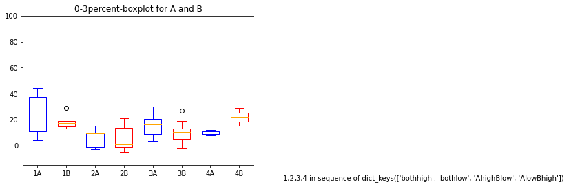

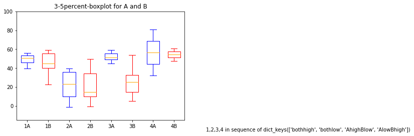

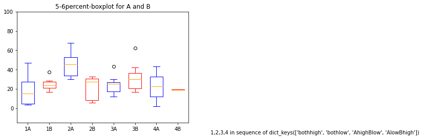

```python
percentage_columns = ['0-3percent','3-5percent','5-6percent']
for p in range(len(percentage_columns)):
    pos = 0;
    fig = figure()
    ax = axes()
    for key in group:
        g = group[key]
        df_TEWL_group = df_TEWL[df_TEWL.id.isin(g)]
        boxlist = []
        boxlist += [(df_TEWL_group[df_TEWL_group.IP=='A'])[percentage_columns[p]]]
        boxlist += [(df_TEWL_group[df_TEWL_group.IP=='B'])[percentage_columns[p]]]
        bp = plt.boxplot(boxlist, positions = [pos+1, pos+2], widths = 0.6)
        setBoxColors(bp)
        pos+=2

    ax.set_xticklabels(['1A','1B','2A','2B', '3A','3B', '4A','4B'])
    title = percentage_columns[p]+'-boxplot for A and B'
    plt.title(title)
    plt.ylim([-15,100])
#     ax.legend()
    txt = str(group.keys())
    fig.text(1, .05, "1,2,3,4 in sequence of "+txt, ha='left')
    plt.savefig('reportplots/'+title+'.png')
    plt.show()
```

##### 0-3 consistent with final group

##### 3-5 consistent with final group except AlowBhigh (could be cause group size of this is 2 )

##### 3-5 shows a larger/clearer difference for grouping

```python
df_TEWLA = df_TEWL[df_TEWL.IP =='A']
df_TEWLB = df_TEWL[df_TEWL.IP =='B']
pct_list = list(df_TEWLA['0-3']/df_TEWLA['maxA-0']*100)+list((df_TEWLB['0-3']/df_TEWLB['maxB-0']*100))
df_TEWL['0-3percent0'] = pct_list
pct_list = list(df_TEWLA['3-5']/df_TEWLA['maxA-0']*100)+list((df_TEWLB['3-5']/df_TEWLB['maxB-0']*100))
df_TEWL['3-5percent0'] = pct_list
pct_list = list(df_TEWLA['5-6']/df_TEWLA['maxA-0']*100)+list((df_TEWLB['5-6']/df_TEWLB['maxB-0']*100))
df_TEWL['5-6percent0'] = pct_list
```

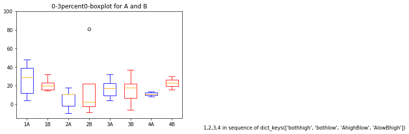

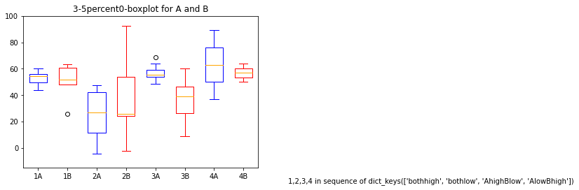

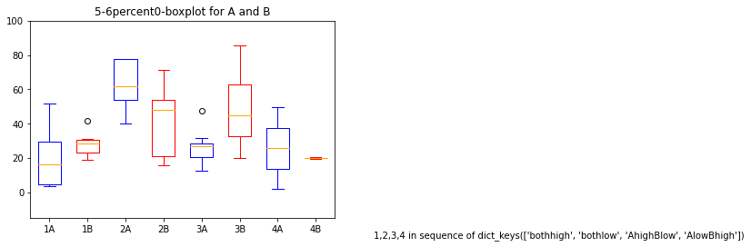

```python
percentage_columns = ['0-3percent0','3-5percent0','5-6percent0']
for p in range(len(percentage_columns)):
    pos = 0;
    fig = figure()
    ax = axes()
    for key in group:
        g = group[key]
        df_TEWL_group = df_TEWL[df_TEWL.id.isin(g)]
        boxlist = []
        boxlist += [(df_TEWL_group[df_TEWL_group.IP=='A'])[percentage_columns[p]]]
        boxlist += [(df_TEWL_group[df_TEWL_group.IP=='B'])[percentage_columns[p]]]
        bp = plt.boxplot(boxlist, positions = [pos+1, pos+2], widths = 0.6)
        setBoxColors(bp)
        pos+=2

    ax.set_xticklabels(['1A','1B','2A','2B', '3A','3B', '4A','4B'])
    plt.title(percentage_columns[p]+'-boxplot for A and B')
    plt.ylim([-15,100])
#     ax.legend()
    txt = str(group.keys())
    fig.text(1, .05, "1,2,3,4 in sequence of "+txt, ha='left')
    plt.show()
```

##### trend now so clear if we use TEWL6-TEWL0 as the denominator

# plot stacked column for each group (percentage based on maxA, maxB)

- as a reference, but very helpful for analysis

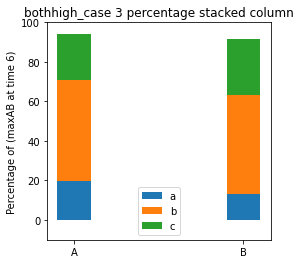

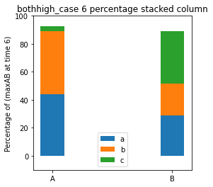

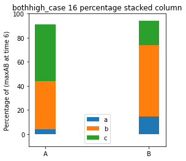

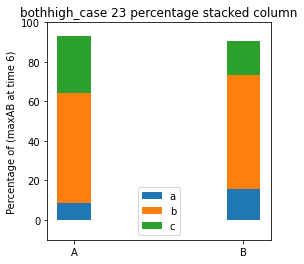

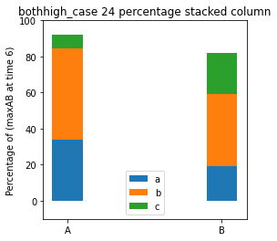

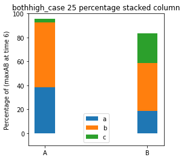

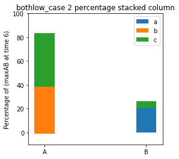

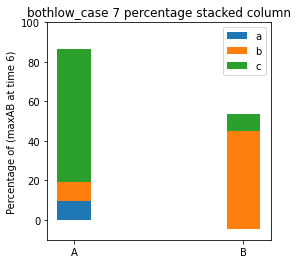

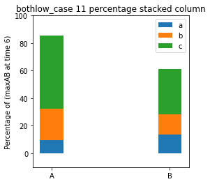

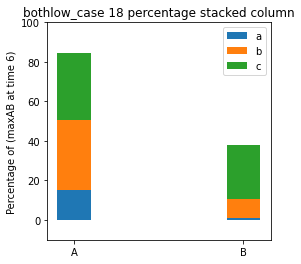

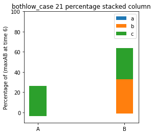

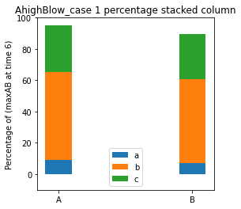

[13 more figures not shown]

```python
bothhigh =[3,6,16,23,24,25]
bothlow = [2,7,11,18,21]
AhighBlow=[1,4,5,8,9,10,12,13,14,15,20,22]
AlowBhigh=[17,19]
group = {'bothhigh':bothhigh, 'bothlow':bothlow,'AhighBlow':AhighBlow,'AlowBhigh':AlowBhigh}
for key in group:
    g = group[key]
    for i in g:
        fig, ax = plt.subplots(figsize=(4,4))
        labels = ['A','B']
        a = (df_TEWL[df_TEWL.id == i])['0-3percent']
        b = (df_TEWL[df_TEWL.id == i])['3-5percent']
        c = (df_TEWL[df_TEWL.id == i])['5-6percent']
        width= 0.2
        ax.bar(labels, a, width,  label='a')
        ax.bar(labels, b, width,  bottom=a,label='b')
        ax.bar(labels, c, width,  bottom=a+b,label='c')

        ax.set_ylabel('Percentage of (maxAB at time 6)')
        ax.set_title(key +'_case '+str(i)+' percentage stacked column')
        ax.legend()
        plt.ylim([-10,100])

        plt.savefig(key+'-case '+str(i))
        plt.show()
```

```python
# percentage_columns = ['0-3percent','3-5percent','5-6percent']
# for ip in ['A','B']:
#     for p in range(0,1):
#         boxdict={}
#         for key in group:
#             g = group[key]
#             df_TEWL_group = df_TEWL[df_TEWL.id.isin(g)]
#             boxdict[key]=(df_TEWL_group[df_TEWL_group.IP==ip])[percentage_columns[p]]
#     #         print(wilcoxon(boxdict['A'],boxdict['B']))
#         plt.boxplot(boxdict.values(),labels=group.keys())
#         plt.title(percentage_columns[p]+' for '+ip)
#         plt.show()
```

```python
! jupyter nbconvert Percentage.ipynb --template toc2
```

```
[NbConvertApp] Converting notebook Percentage.ipynb to html
[NbConvertApp] Writing 1105773 bytes to Percentage.html
```